# Curs d’introducció a R

01 de de juliol de 2025

## Primera sessió amb R

## Baixar i instal·lar R

R és un llenguatge de programació, però s’instal·la a l’ordinador com qualsevol altre programa. El podeu trobar a:

> https://cran.r-project.org/

On trobareu versions per linux, mac i windows.

Baixeu-vos l’última versió disponible, que en el moment d’escriure aquest text és la 4.5.1.

Seguiu després les instruccions per instal·lar-lo al vostre ordinador.

## RStudio

Una vegada instal·lat R ja el podem utilitzar, el que passa és que és difícil d’utilitzar com a tal, i per això fem servir un IDE (Entorn integrat de desenvolupament (en anlgès)), que bàsicament ens facilita la vida a l’hora de programar

L’IDE més utilitzat per R és RStudio, i és el que nosaltres utilitzarem. El podeu trobar a:

**mac**: https://medium.com/@GalarnykMichael/install-r-and-rstudio-on-mac-e911606ce4f4

**Windows**: https://medium.com/@GalarnykMichael/install-r-and-rstudio-on-windows-5f503f708027

**LINUX**: https://medium.com/@GalarnykMichael/install-r-and-rstudio-on-ubuntu-12-04-14-04-16-04-b6b3107f7779

Seguiu també les instruccions per instal·lar-lo.

## Studio

[figure not shown]

## Consola

- Aquest símbol “>” és el prompt i és on haurem d’escriure les nostres ordres.
- Aquest símbol “#” serveix per introduir un comentari.

## Consola

- Si ens equivoquem podem pitgem la tecla “ESC” i tornarà a aparèixer el símbol “>”
- Podem navegar per les instruccions que ja hem executat fent servir les tecles

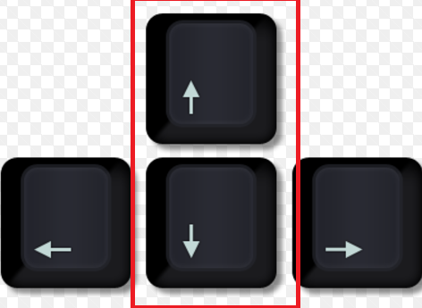

- Per sortir del programa podem tancar o executar “>q()”

## Paquets i les llibreries

- R consta d’un sistema “base”, que inclou molts mètodes estadístics, i un sistema per paquets que permeten anar molt més enllà.
- A sobre d’aquí, hi ha conjunts de paquets que s’anomenen dialectes, que són conjunts de paquets que segueixen la mateixa filosofia.
- Finalment, hi ha paquets amb eines extres que s’anomenen “llibreries”, i que instal·larem quan ho necessitem.

## Paquets i les llibreries

Triem un repositori:

```r
install.packages("readr") # Importar dades de text
```

Un cop instal·lat l’haurem de carregar a la biblioteca:

```r
library(readr)
```

## Llenguatge interpretat

- R és un llenguatge interpretat, per això no cal compilar.
- Per executar una ordre, només cal escriure-la i pulsar “Enter”.
- Exemples:

```r
4 + 5
```

```
## [1] 9
```

```r
sqrt(49)
```

```
## [1] 7
```

```r
log(2)
```

```
## [1] 0.6931472
```

## Funcions

- Una funció és un conjunt d’ordres que es poden executar amb un sol nom.
- Per exemple, la funció `sqrt()` calcula la arrel quadrada d’un nombre.
- Les funcions tenen paràmetres, que són els valors que li passem per a que la funció funcioni.
- Els paràmetres poden ser:
- **Obligatoris**: són els que no tenen valor per defecte i s’han de posar.
- **Opcionals**: són els que tenen valor per defecte i s’han de posar si volem canviar el valor per defecte.

## Funcions

Per exemple, la funció `sqrt()` té un paràmetre obligatori, que és el nombre del qual volem calcular l’arrel quadrada.

```r
sqrt(49)
```

```
## [1] 7
```

- Per exemple, la funció `rnorm()` té dos paràmetres opcionals, que són el nombre de nombres aleatoris que volem generar i la mitjana i la desviació estàndard de la distribució normal.

```r
rnorm(3, mean = 0, sd = 1)
```

```
## [1]  1.3359118 -0.4819097 -0.8298912
```

## Funcions

Els paràmetres es poden passar per posició o per nom.

```r
rnorm(3, 0, 1)
```

```
## [1] 0.02519509 0.47088602 1.19618321
```

```r
rnorm(n = 3, mean = 0, sd = 1)
```

```
## [1]  1.0644952 -0.2135213 -0.0246629
```

## Funcions: ajuda

```r
?sample
```

- Ens surt una informació com aquesta:

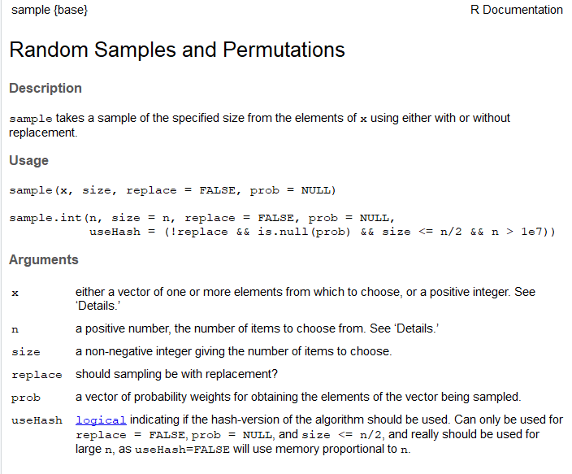

## Espai de treball

- És l’espai on es desen tots els objectes que anem creant o carregant.
- Quan tanquem el programa el podem desar.

```r
getwd() #on és el meu espai de treball
ls() #quins objectes hi ha?

setwd("PATH") # hem de substituir el "path" pel de l'espai de
# treball on volem estar
```

## Objectes

## Variables

- Les variables són els objectes més simple i poden ser:
1. numèric: números reals (3.1415)
2. complex: números complexes (2 + 5i)
3. character: cadenes alfanumèriques de text (“patata”)
4. factor: variables categòriques (sexe, color, etc.)
5. logical: variables lògiques (TRUE)

## Objectes

- Els objectes són elements que es guarden en l’espai de treball (és a dir, en la memòria RAM).
- Un objecte pot contenir un o més elements.

```r
w <- 3 + 4 # Creem l'objecte w
print(w)
```

```
## [1] 7
```

## Tipus d’objectes

- Bàsicament podem identificar 4 tipus d’objectes:
1. Vectors
2. Matrius
3. Dataframes
4. Llistes

En aquest curs treballarem vectors i dataframes.

## Tipus d’objectes: vectors

- És una col·lecció ordenada d’elements del **mateix tipus** (numèric, factor…)
- Es creen amb la funció c()

```r
x <- c(2, 4, 6) # Vector de 3 elements numèrics parells
x
```

```
## [1] 2 4 6
```

```r
y <- c("A", "B", "C") # Vector de 3 elements cadena
y
```

```
## [1] "A" "B" "C"
```

```r
z <- c(TRUE, FALSE, TRUE) # Vector de 3 elements lògics
z
```

```
## [1]  TRUE FALSE  TRUE
```

## Algunes operacions: vectors

```r
x <- 1:10 # Genera un vector d'1 a 10
x
```

```
##  [1]  1  2  3  4  5  6  7  8  9 10
```

```r
x[4] # La posició 4 és
```

```
## [1] 4
```

```r
x[x > 7] # Elements més grans de 7
```

```
## [1]  8  9 10
```

```r
x + 2 # Sumar un nombre
```

```
##  [1]  3  4  5  6  7  8  9 10 11 12
```

## Tipus d’objectes: dataframes

- És una col·lecció ordenada d’elements de **qualsevol tipus** amb dues dimensions.

```r
library(tibble)

id <- 1:10

sexe <- rep(c("M", "D"), 5)

normal <- rnorm(10)

curacio <- rep(c(FALSE, TRUE), 5)

dades <- tibble(id, sexe, normal, curacio)

head(dades) # Mostrar primeres files/registres
```

```
## # A tibble: 6 × 4
##      id sexe  normal curacio
##   <int> <chr>  <dbl> <lgl>
## 1     1 M      0.708 FALSE
## 2     2 D      0.908 TRUE
## 3     3 M      0.812 FALSE
## 4     4 D     -1.09  TRUE
## 5     5 M     -1.11  FALSE
## 6     6 D      0.447 TRUE
```

## Manipulació de dades

## Introducció

Ara utilitzarem les funcions del paquet **dplyr** per fer les subseleccions més habituals.  
Algunes de les funcions bàsiques són:

- `select()` – escull columnes
- `slice()` – escull files per posició
- `filter()` – escull files que compleixen una condició
- `arrange()` – ordena files
- `mutate()` – crea o transforma variables

Això ho farem amb el paquet ‘dplyr’

```r
library(dplyr)
```

## Subseleccions

```r
# Seleccionem una cel·la concreta: fila 2
slice(dades, 2)
```

```
## # A tibble: 1 × 4
##      id sexe  normal curacio
##   <int> <chr>  <dbl> <lgl>
## 1     2 D      0.908 TRUE
```

```r
# Seleccionem una fila, per exemple de la 4 a la 10
slice(dades, 4:10)
```

```
## # A tibble: 7 × 4
##      id sexe  normal curacio
##   <int> <chr>  <dbl> <lgl>
## 1     4 D     -1.09  TRUE
## 2     5 M     -1.11  FALSE
## 3     6 D      0.447 TRUE
## 4     7 M     -0.764 FALSE
## 5     8 D      0.608 TRUE
## 6     9 M      0.924 FALSE
## 7    10 D      1.33  TRUE
```

```r
# També ho podem fer pel nom de la variable
select(dades, normal)
```

```
## # A tibble: 10 × 1
##    normal
##     <dbl>
##  1  0.708
##  2  0.908
##  3  0.812
##  4 -1.09
##  5 -1.11
##  6  0.447
##  7 -0.764
##  8  0.608
##  9  0.924
## 10  1.33
```

```r
# També ho podem fer amb el símbol del dòlar "$"
dades$normal
```

```
##  [1]  0.7077186  0.9076448  0.8121048 -1.0853033 -1.1076746  0.4469169
##  [7] -0.7643224  0.6075406  0.9244691  1.3286645
```

## Subseleccions

```r
# Seleccionem un conjunt de columnes
select(dades, id, sexe, normal)
```

```
## # A tibble: 10 × 3
##       id sexe  normal
##    <int> <chr>  <dbl>
##  1     1 M      0.708
##  2     2 D      0.908
##  3     3 M      0.812
##  4     4 D     -1.09
##  5     5 M     -1.11
##  6     6 D      0.447
##  7     7 M     -0.764
##  8     8 D      0.608
##  9     9 M      0.924
## 10    10 D      1.33
```

```r
# O totes menys algunes
select(dades, -id, -normal)
```

```
## # A tibble: 10 × 2
##    sexe  curacio
##    <chr> <lgl>
##  1 M     FALSE
##  2 D     TRUE
##  3 M     FALSE
##  4 D     TRUE
##  5 M     FALSE
##  6 D     TRUE
##  7 M     FALSE
##  8 D     TRUE
##  9 M     FALSE
## 10 D     TRUE
```

## Subseleccions

```r
# Creem un nou objecte amb la subselecció
dades2 <- select(dades, id, sexe, normal)

head(dades2)
```

```
## # A tibble: 6 × 3
##      id sexe  normal
##   <int> <chr>  <dbl>
## 1     1 M      0.708
## 2     2 D      0.908
## 3     3 M      0.812
## 4     4 D     -1.09
## 5     5 M     -1.11
## 6     6 D      0.447
```

## Filtres

```r
# Subseleccionar amb una condició lògica
dones <- filter(dades, sexe == "D")
head(dones)
```

```
## # A tibble: 5 × 4
##      id sexe  normal curacio
##   <int> <chr>  <dbl> <lgl>
## 1     2 D      0.908 TRUE
## 2     4 D     -1.09  TRUE
## 3     6 D      0.447 TRUE
## 4     8 D      0.608 TRUE
## 5    10 D      1.33  TRUE
```

```r
# Un altre exemple
grans <- filter(dades, normal > 1.96)
head(grans)
```

```
## # A tibble: 0 × 4
## # ℹ 4 variables: id <int>, sexe <chr>, normal <dbl>, curacio <lgl>
```

## L’operador pipe

L’operador pipe `|>` ens permet **encadenar** funcions de manera llegible:

- Passa el resultat de l’esquerra com a **primer argument** de la funció de la dreta
- Ens estalvia crear variables intermèdies
- Fa el codi més llegible i natural
- També es pot escriure com a ‘%>%’, són equivalents però lleugerament diferents.

## L’operador pipe

Exemple:

**Sense pipe:**

```r
resultat <- select(filter(dades, sexe == "D"), id, normal)
```

**Amb pipe:**

```r
resultat <- dades |>
  filter(sexe == "D") |>
  select(id, normal)
```

Es llegeix com: “agafa `dades`, després filtra per sexe femení, després selecciona id i normal”

## Llegir dades externes

## Paquets del tidyverse per a la lectura de dades

- **readr** : fitxers de text (*.csv, *.tsv, *.txt …)
- **readxl** : fulls de càlcul Excel (*.xls, *.xlsx)
- **haven** : fitxers d’altres programes estadístics (SPSS, Stata, SAS)

Totes aquestes funcions retornen un **tibble** i encaixen a la perfecció amb la resta del flux `tidyverse`.

```r
library(readr)  # read_csv(), read_delim(), …
library(readxl) # read_excel()
library(haven)  # read_spss(), read_dta(), read_sas()
```

### Importar fitxers de text (.csv, .tsv, …)

```r
# Fitxer CSV amb separador ","
dades <- read_csv("ruta/fitxer.csv", show_col_types = FALSE)

# Fitxer delimitat per punt i coma
dades <- read_delim("ruta/fitxer.csv", delim = ";", show_col_types = FALSE)

# o
dades <- read_csv2("ruta/fitxer.csv")

# Fitxer delimitat per tabulador
dades <- read_tsv("ruta/fitxer.tsv")
```

### Importar fitxers Excel

```r
full <- read_excel("ruta/fitxer.xlsx", sheet = "Full1")
```

### Importar fitxers SPSS / Stata / SAS

```r
enc   <- read_spss("ruta/dades.sav")      # SPSS
stata <- read_dta("ruta/dades.dta")       # Stata
sas   <- read_sas("ruta/dades.sas7bdat") # SAS
```

### Exemple

```r
# Llegim les dades d'exemple amb readr
dades <- read_csv("input/dades.csv", show_col_types = FALSE)
```

## Exploració de les dades

## Estructura

Fem una ullada a les dades

```r
str(dades) # mostra estructura d'un objecte
```

```
## spc_tbl_ [10 × 7] (S3: spec_tbl_df/tbl_df/tbl/data.frame)
##  $ id     : num [1:10] 1 2 3 4 5 6 7 8 9 10
##  $ sexe   : chr [1:10] "M" "D" "M" "D" ...
##  $ normal : num [1:10] 0.501 -0.309 -0.657 -0.779 -1.681 ...
##  $ curacio: logi [1:10] FALSE TRUE FALSE TRUE FALSE TRUE ...
##  $ edat   : num [1:10] 67 78 89 86 56 90 68 82 92 67
##  $ alçada : num [1:10] 173 184 145 178 184 ...
##  $ pes    : num [1:10] 81.9 72 73.5 96.3 88.5 ...
##  - attr(*, "spec")=
##   .. cols(
##   ..   id = col_double(),
##   ..   sexe = col_character(),
##   ..   normal = col_double(),
##   ..   curacio = col_logical(),
##   ..   edat = col_double(),
##   ..   alçada = col_double(),
##   ..   pes = col_double()
##   .. )
##  - attr(*, "problems")=<externalptr>
```

## Estructura

```r
glimpse(dades) # forma de tidyverse
```

```
## Rows: 10
## Columns: 7
## $ id      <dbl> 1, 2, 3, 4, 5, 6, 7, 8, 9, 10
## $ sexe    <chr> "M", "D", "M", "D", "M", "D", "M", "D", "M", "D"
## $ normal  <dbl> 0.5010061, -0.3094905, -0.6568773, -0.7792013, -1.6813112, 0.6…
## $ curacio <lgl> FALSE, TRUE, FALSE, TRUE, FALSE, TRUE, FALSE, TRUE, FALSE, TRUE
## $ edat    <dbl> 67, 78, 89, 86, 56, 90, 68, 82, 92, 67
## $ alçada  <dbl> 172.7174, 183.9688, 145.0844, 177.6097, 183.7038, 160.0296, 16…
## $ pes     <dbl> 81.90518, 71.97999, 73.50533, 96.31974, 88.46697, 65.58480, 65…
```

## Primeres / últimes files

```r
head(dades) # mostra les primeres files
```

```
## # A tibble: 6 × 7
##      id sexe  normal curacio  edat alçada   pes
##   <dbl> <chr>  <dbl> <lgl>   <dbl>  <dbl> <dbl>
## 1     1 M      0.501 FALSE      67   173.  81.9
## 2     2 D     -0.309 TRUE       78   184.  72.0
## 3     3 M     -0.657 FALSE      89   145.  73.5
## 4     4 D     -0.779 TRUE       86   178.  96.3
## 5     5 M     -1.68  FALSE      56   184.  88.5
## 6     6 D      0.661 TRUE       90   160.  65.6
```

```r
tail(dades) # mostra les últimes files
```

```
## # A tibble: 6 × 7
##      id sexe  normal curacio  edat alçada   pes
##   <dbl> <chr>  <dbl> <lgl>   <dbl>  <dbl> <dbl>
## 1     5 M     -1.68  FALSE      56   184.  88.5
## 2     6 D      0.661 TRUE       90   160.  65.6
## 3     7 M      0.517 FALSE      68   166.  66.0
## 4     8 D      1.43  TRUE       82   159.  74.6
## 5     9 M      0.534 FALSE      92   161.  62.0
## 6    10 D      0.981 TRUE       67   169.  81.6
```

## Tota la taula (en una finestra nova)

```r
View(dades) # mostra tot el conjunt de dades
```

## Manipulació de variables

## Creació de noves variables

Fem servir `mutate()` per afegir columnes al nostre tibble:

```r
dades <- dades |>
  mutate(
    alçada_metres = alçada / 100,
    imc    = pes / alçada_metres ^ 2   # índex de massa corporal
  )
```

## Visualitzem

```r
head(dades)
```

```
## # A tibble: 6 × 9
##      id sexe  normal curacio  edat alçada   pes alçada_metres   imc
##   <dbl> <chr>  <dbl> <lgl>   <dbl>  <dbl> <dbl>         <dbl> <dbl>
## 1     1 M      0.501 FALSE      67   173.  81.9          1.73  27.5
## 2     2 D     -0.309 TRUE       78   184.  72.0          1.84  21.3
## 3     3 M     -0.657 FALSE      89   145.  73.5          1.45  34.9
## 4     4 D     -0.779 TRUE       86   178.  96.3          1.78  30.5
## 5     5 M     -1.68  FALSE      56   184.  88.5          1.84  26.2
## 6     6 D      0.661 TRUE       90   160.  65.6          1.60  25.6
```